# Lab 5B: Statistical Modeling (Hard)

1. Set the working directory
2. Load policies from the CSV file

### Problem 1: Create a Gaussian Distribution Model of Height

3. Create a plot of height (Centimeters)

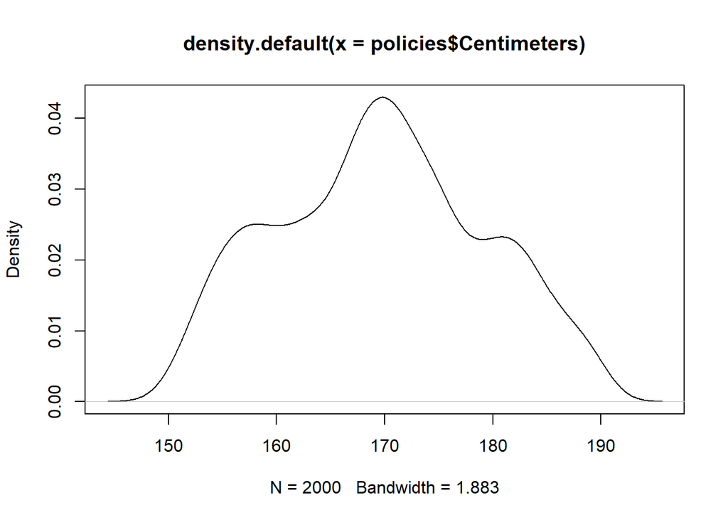

4. Get the mean
5. Print the mean

```
## [1] 169.632
```

6. Get the standard deviation
7. Print the standard devition

```
## [1] 9.567358
```

8. Create points along x-axis of the distribution
9. Compute the y-axis height of each point
10. Add the distribution to the plot

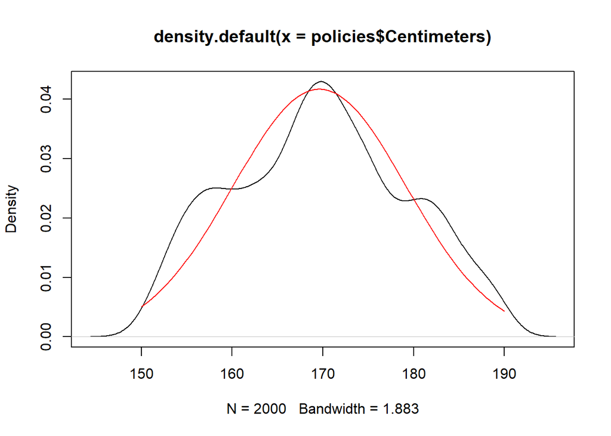

```r
plot(density(policies$Centimeters))
lines(
  x = distributionX,
  y = distributionY,
  col = "red")
```

11. Generate new values from the model
12. Add distribution of generated values to plot

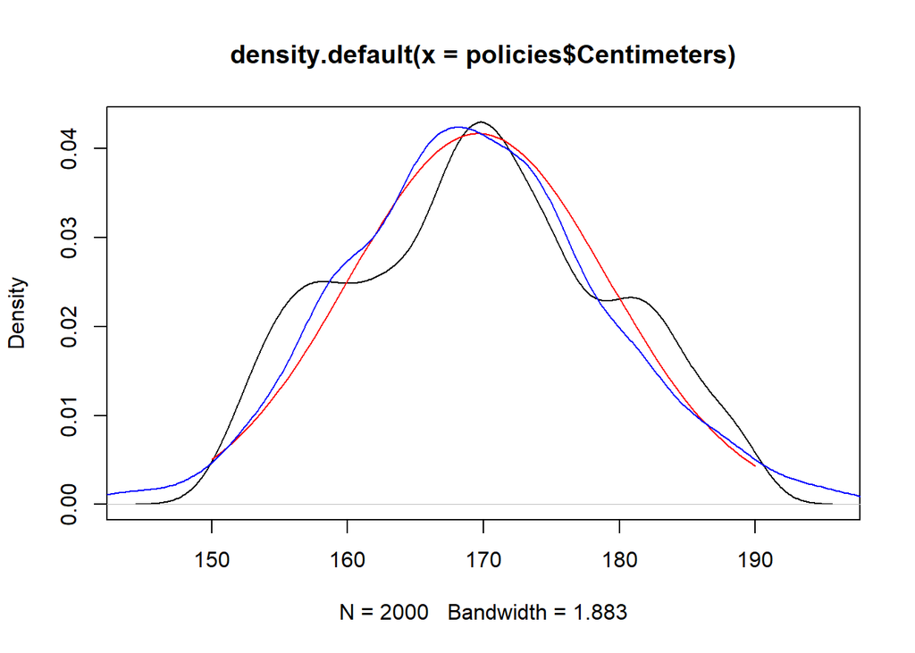

13. Get the mean of the generated values

```
## [1] 169.2888
```

9. Get the standard deviation of the generated values

```
## [1] 9.590691
```

Question: What would happen to the mean and standard deviation if we increase n to 1,000,000?

### Problem 2: Create a Simple Linear Regression Model

10. Create a scatterplot of height (Centimeters) vs weight (Kilograms)

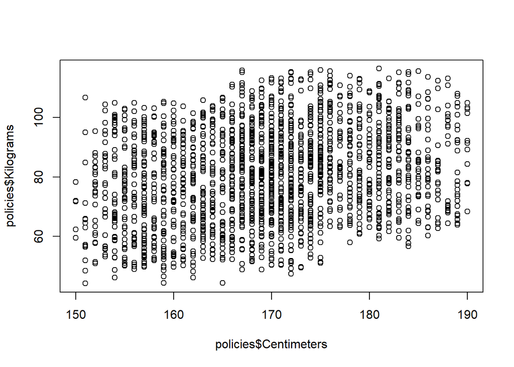

11. Create a linear regression model
12. Draw the linear regression model on the plot

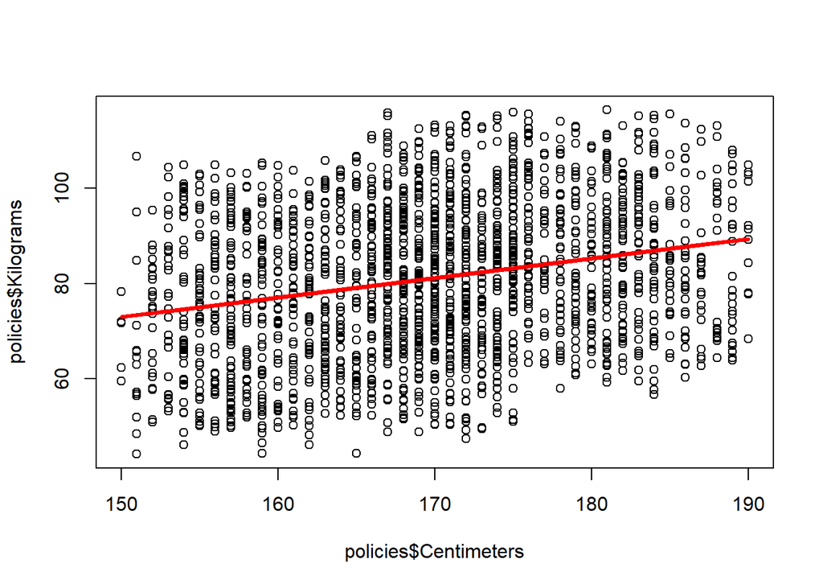

13. Get the correlation coefficient

```
## [1] 0.2467215
```

14. Summarize the model

```
##
## Call:
## lm(formula = Kilograms ~ Centimeters, data = policies)
##
## Residuals:
##     Min      1Q  Median      3Q     Max
## -34.914 -12.678  -0.038  12.247  35.962
##
## Coefficients:
##             Estimate Std. Error t value Pr(>|t|)
## (Intercept) 11.12801    6.15165   1.809   0.0706 .
## Centimeters  0.41204    0.03621  11.380   <2e-16 ***
## ---
## Signif. codes:  0 '***' 0.001 '**' 0.01 '*' 0.05 '.' 0.1 ' ' 1
##
## Residual standard error: 15.49 on 1998 degrees of freedom
## Multiple R-squared:  0.06087,    Adjusted R-squared:  0.0604
## F-statistic: 129.5 on 1 and 1998 DF,  p-value: < 2.2e-16
```

15. Create a table of unseen heights: 150, 175, 200
16. Predict new unknown weights based new unseen heights

```
##        1        2        3
## 72.93363 83.23457 93.53550
```

Question are their any problems with this linear regression model?

17. Create a scatterplot of Age vs Rate

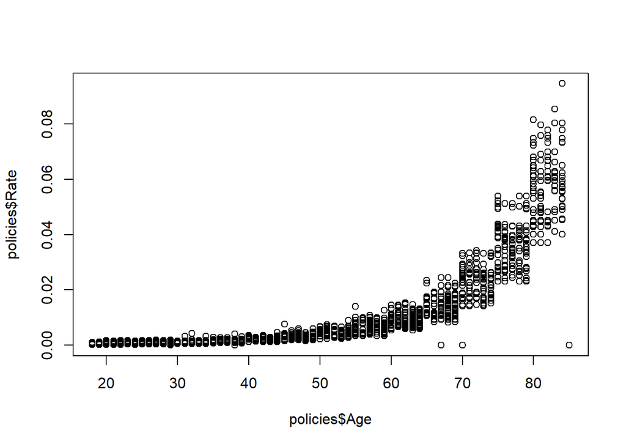

18. Get the correlation coefficient

```
## [1] 0.7387237
```

Question: Why is a linear model not a good model for these data?